# 第7章の課題と模範解答

藤野秀則,

2025-06-16

# 1 課題1

ある自治体の高校生を対象に朝食摂取と成績の関係を明らかにするために調査をおこない，このようなデータを取得した．この調査では，調査日（抜き打ち実施）に朝食を食べているかどうかと，4限目の授業で実施した数学のテストの得点がデータとして取得されている．このデータについて，以下の課題を実施せよ．

1. このデータの冒頭6行分をhead()を用いて確認し，このデータがワイド形式かロング形式か確認せよ．
2. 摂取群と欠食群のそれぞれの平均と標準偏差（こちらで述べている通り推測統計量でよい）を算出するとともに，それらを棒グラフで示せ．棒グラフにはエラーバーも付与すること．
3. 朝食を食べている人と食べていない人とで数学のテストの得点に有意な差があるかどうかを検証せよ．
4. 先に描いた棒グラフ上にt検定の結果を示すブラケットを書き入れよ．

```r
mydata_work1 <- read.csv(
  "./practice/07_work_1.csv",
  header=T,
  fileEncoding="UTF8"
) # データ読み込み

# 1. データの確認
head(mydata_work1)
```

```
##   朝食 得点
## 1 欠食   53
## 2 欠食   47
## 3 摂取   36
## 4 欠食   30
## 5 摂取   40
## 6 摂取   57
```

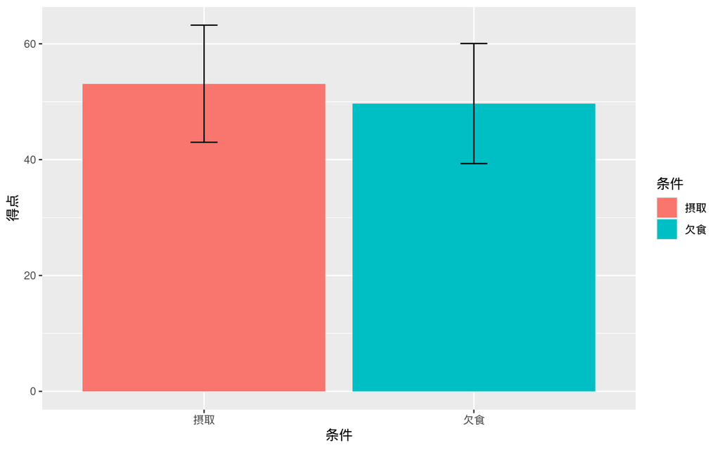

```r
# 2. 平均と標準偏差の算出
平均<-aggregate(得点~朝食, mydata_work1, mean)
標準偏差<-aggregate(得点~朝食, mydata_work1, sd)

#データフレームの作成
mydf <- data.frame(
  条件=平均$朝食,
  得点=平均$得点,
  標準偏差=標準偏差$得点
)

# ggplotで棒グラフを表示
g<- ggplot(data=mydf)+
  geom_bar(aes(x=条件, y=得点, fill=条件), stat="identity")+
  geom_errorbar(aes(x=条件, ymin=得点-標準偏差, ymax=得点+標準偏差, width=0.1))
plot(g)
```

```r
# 3. t検定
t.test(得点~朝食, mydata_work1)
```

```
##
##  Welch Two Sample t-test
##
## data:  得点 by 朝食
## t = 10.07, df = 2845.5, p-value < 2.2e-16
## alternative hypothesis: true difference in means between group 摂取 and group 欠食 is not equal to 0
## 95 percent confidence interval:
##  2.755725 4.088434
## sample estimates:
## mean in group 摂取 mean in group 欠食
##           53.10596           49.68388
```

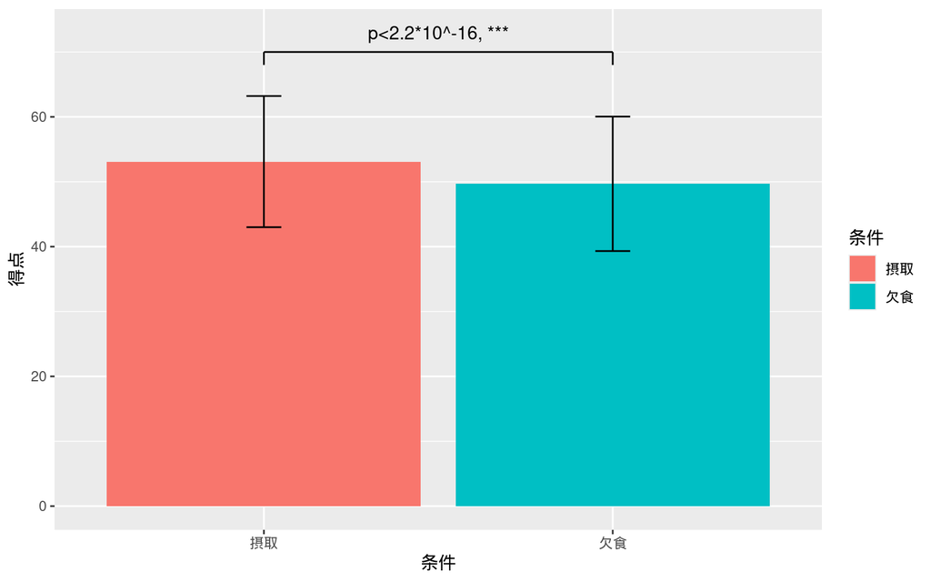

```r
# 4. ブラケットの追加
g<- ggplot(data=mydf)+
  geom_bar(aes(x=条件, y=得点, fill=条件), stat="identity")+
  geom_errorbar(aes(x=条件, ymin=得点-標準偏差, ymax=得点+標準偏差, width=0.1))+
  annotate("segment",x=1, xend=1, y=68, yend=70)+
  annotate("segment",x=1, xend=2, y=70, yend=70)+
  annotate("segment",x=2, xend=2, y=70, yend=68)+
  annotate("text",x=1.5, y=73, label="p<2.2*10^-16, ***", size=4)
plot(g)
```

# 2 課題2

あるショコラティエで，新しいチョコレートの試作に取り組んでいる．同じチョコレートでも，どのような形に成形するかで，味の評価が変わるのではないかと考え，店に来店したお客さん50人にそれぞれを食べてもらい，おいしさを10段階で評価してもらい，次のようなデータを取得した．このデータについて，以下の課題を実施せよ．

1. このデータの冒頭6行分をhead()を用いて確認し，このデータがワイド形式かロング形式か確認せよ．
2. 形状Aと形状Bのそれぞれの平均と標準偏差を算出するとともに，それらを棒グラフで示せ．棒グラフにはエラーバーも付与すること．
3. 形状Aと形状Bとでおいしさに有意な差があるかどうかを検証せよ．
4. 先に描いた棒グラフ上にt検定の結果を示すブラケットとt検定の結果えられた有意確率を書き入れよ．

```r
mydata_work2 <- read.csv(
  "./practice/07_work_2.csv",
  header=T,
  fileEncoding="UTF8"
) # データ読み込み

# 1. データの確認
head(mydata_work2)
```

```
##   No. 形状A 形状B
## 1   1     6     6
## 2   2     5     2
## 3   3     7     9
## 4   4     9     5
## 5   5     7     6
## 6   6     8     8
```

```r
# 2. 平均と標準偏差の算出
平均<-c(mean(mydata_work2$形状A), mean(mydata_work2$形状B))
標準偏差<-c(sd(mydata_work2$形状A), sd(mydata_work2$形状B))

#データフレームの作成
mydf <- data.frame(
  条件=c("形状A", "形状B"),
  おいしさ=平均,
  標準偏差=標準偏差
)
print(mydf)
```

```
##    条件 おいしさ 標準偏差
## 1 形状A     6.02 1.362621
## 2 形状B     6.72 2.213502
```

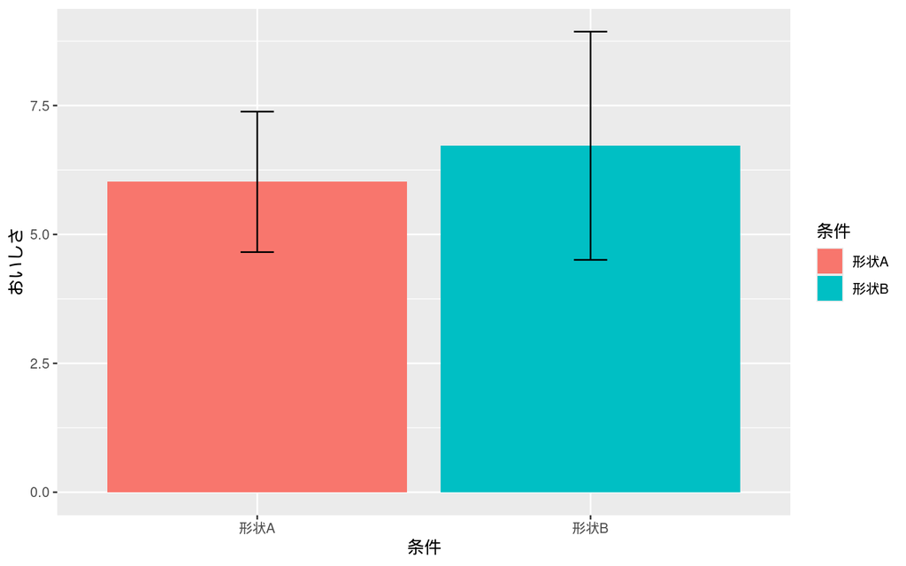

```r
#グラフ
g<-ggplot(mydf)+
  geom_bar(aes(x=条件, y=おいしさ, fill=条件), stat="identity")+
  geom_errorbar(aes(x=条件, ymin=おいしさ-標準偏差, ymax=おいしさ+標準偏差, width=0.1))
plot(g)
```

```r
# t検定
A <- mydata_work2$形状A
B <- mydata_work2$形状B
t.test(A, B, paired=TRUE)
```

```
##
##  Paired t-test
##
## data:  A and B
## t = -2.3548, df = 49, p-value = 0.02258
## alternative hypothesis: true mean difference is not equal to 0
## 95 percent confidence interval:
##  -1.2973793 -0.1026207
## sample estimates:
## mean difference
##            -0.7
```

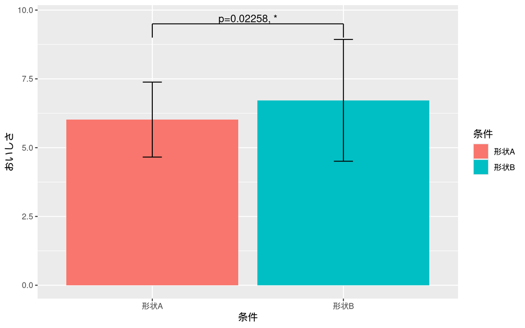

```r
# ブラケットの追加
g<-ggplot(mydf)+
  geom_bar(aes(x=条件, y=おいしさ, fill=条件), stat="identity")+
  geom_errorbar(aes(x=条件, ymin=おいしさ-標準偏差, ymax=おいしさ+標準偏差, width=0.1))+
  annotate("segment",x=1, xend=1, y=9, yend=9.5)+
  annotate("segment",x=1, xend=2, y=9.5, yend=9.5)+
  annotate("segment",x=2, xend=2, y=9, yend=9.5)+
  annotate("text",x=1.5, y=9.7, label="p=0.02258, *", size=4)
plot(g)
```

# 3 課題3

ある製品メーカでは公称重量70gの金属部品を製造しているが，製造工程の中でどうしても多少のばらつきが発生してしまうため，69.950g～70.049gまでを許容範囲とし，この範囲を超えるものについては不良品といて品質検査時に弾くことになっている．

今，製品の歩留まり率（検品の際に不良品として弾かれ**なかった**製品の割合）の向上を狙って，製造工程を変更を計画している．この工程変更によって，製品の品質のバラツキが抑えられるかどうかを検証するために，変更前の製造された製品と，試験的に導入した新工程での製品をランダムに200個ずつ取り出してきたデータ．このデータを用いて，以下のことを行え．

1. このデータの冒頭6行分をhead()を用いて確認し，このデータの形式か確認せよ．
2. 変更前と変更後のそれぞれの平均と標準偏差を算出するとともに，それらを棒グラフで示せ．棒グラフにはエラーバーも付与すること．なお，y軸の変域は[69.9, 70.1]とせよ（ヒント：coord_cartesian(ylim = c(69.90, 70.10))を加える）．
3. 変更前と変更後とで品質検査の点数そのものに有意な差があるかどうかを検証せよ．
4. 変更前と変更後とで品質検査の点数のバラツキに有意な差があるかどうかを検証せよ．

```r
mydata_work3 <- read.csv(
  "./practice/07_work_3.csv",
  header=T,
  fileEncoding="UTF8"
) # データ読み込み

# 平均と標準偏差
平均<-c(mean(mydata_work3$変更前), mean(mydata_work3$変更後))
標準偏差<-c(sd(mydata_work3$変更前), sd(mydata_work3$変更後))

#データフレームの作成
mydf <- data.frame(
  条件=c("変更前", "変更後"),
  品質検査=平均,
  標準偏差=標準偏差
)
print(mydf)
```

```
##     条件 品質検査   標準偏差
## 1 変更前 69.99830 0.05847587
## 2 変更後 70.00032 0.02840921
```

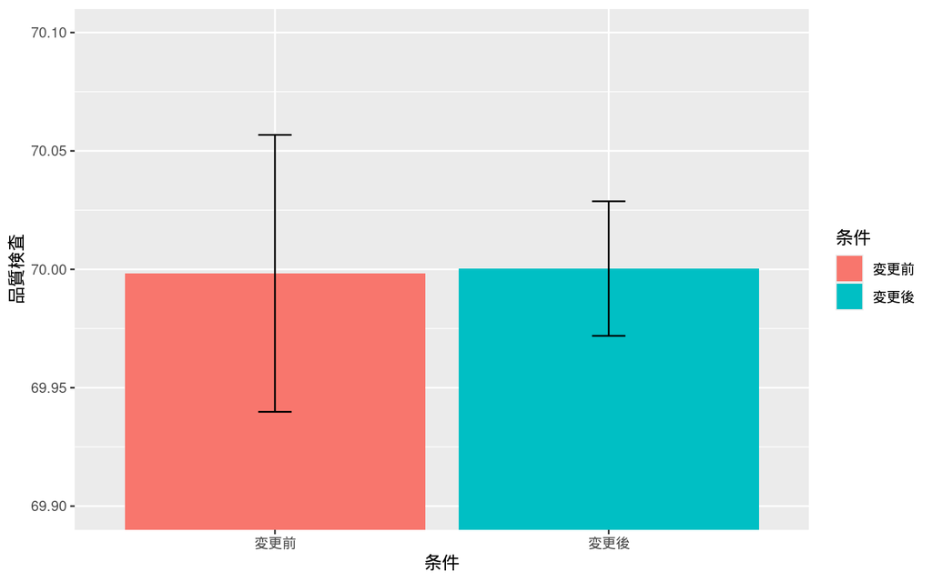

```r
#グラフ
g<-ggplot(mydf)+
  geom_bar(aes(x=条件, y=品質検査, fill=条件), stat="identity")+
  geom_errorbar(aes(x=条件, ymin=品質検査-標準偏差, ymax=品質検査+標準偏差, width=0.1))+
  coord_cartesian(ylim = c(69.90, 70.10))
plot(g)
```

```r
# t検定
t.test(mydata_work3$変更前, mydata_work3$変更後)
```

```
##
##  Welch Two Sample t-test
##
## data:  mydata_work3$変更前 and mydata_work3$変更後
## t = -0.43942, df = 287.98, p-value = 0.6607
## alternative hypothesis: true difference in means is not equal to 0
## 95 percent confidence interval:
##  -0.01106801  0.00702801
## sample estimates:
## mean of x mean of y
##  69.99830  70.00032
```

```r
# F検定
var.test(mydata_work3$変更前, mydata_work3$変更後)
```

```
##
##  F test to compare two variances
##
## data:  mydata_work3$変更前 and mydata_work3$変更後
## F = 4.2368, num df = 199, denom df = 199, p-value < 2.2e-16
## alternative hypothesis: true ratio of variances is not equal to 1
## 95 percent confidence interval:
##  3.206333 5.598372
## sample estimates:
## ratio of variances
##           4.236773
```

# 4 課題4

ある大学3年生の学生が，最近後輩たちが使っているメッセンジャーアプリに違いが出てきているように感じている．具体的には，自分達はLINEを主なメッセンジャーツールとして使っているが，最近の後輩はInstagramのDMを主なツールとして使っているようだ．そこで実際に自分達の世代と後輩世代と使っているメッセンジャーアプリに違いがあるのかをゼミ研究として調査をしてみることにした．

調査は，大学1から4年生の学生約2000人に対して，LINEとInstagramのどちらを主なメッセンジャーツールとして使っているかを尋ねるアンケートをメールで送付した．結果，次のようなデータ（リンク）が得られた．このデータから，先輩群(3，4年生）と後輩群(1，2年生）の間で使っているメッセンジャーアプリに違いがあるのかを検証せよ．

```r
mydata_work4 <- read.csv(
  "./practice/07_work_4.csv",
  header=T,
  fileEncoding="UTF8"
) # データ読み込み

mydata_work4$年代 <- as.factor(mydata_work4$年代)
mydata_work4$SNS <- as.factor(mydata_work4$SNS)
summary(mydata_work4)
```

```
##    年代            SNS
##  先輩:321   Instagram:440
##  後輩:535   LINE     :416
```

```r
#クロス集計表の作成
cross_table <- table(mydata_work4$年代, mydata_work4$SNS)
cross_table
```

```
##
##        Instagram LINE
##   先輩       100  221
##   後輩       340  195
```

```r
# Fisherの正確確率検定
chisq.test(cross_table)
```

```
##
##  Pearson's Chi-squared test with Yates' continuity correction
##
## data:  cross_table
## X-squared = 83.011, df = 1, p-value < 2.2e-16
```

# 5 課題5

ある大学のあるゼミの学生が，ふと「政治学のゼミにいる学生はそのほかのゼミの学生より．選挙に行く人が多いのだろうか」という疑問を抱いた．これを検証するために，実際に最近あった衆議院選挙に投票に行ったかどうかを尋ねるアンケートを行った．その結果，次のようなデータ（リンク）が得られた．このデータから，政治学ゼミの学生とその他のゼミの学生の間で投票に行く人の割合に違いがあるのかを検証せよ．

```r
mydata_work5 <- read.csv(
  "./practice/07_work_5.csv",
  header=T,
  fileEncoding="UTF8"
) # データ読み込み

mydata_work5$ゼミ <- as.factor(mydata_work5$ゼミ)
mydata_work5$投票 <- as.factor(mydata_work5$投票)
summary(mydata_work5)
```

```
##      ゼミ      投票
##  その他:180   No :110
##  政治学: 15   Yes: 85
```

```r
#クロス集計表の作成
cross_table <- table(mydata_work5$ゼミ, mydata_work5$投票)
cross_table
```

```
##
##           No Yes
##   その他 105  75
##   政治学   5  10
```

```r
# Fisherの正確確率検定
fisher.test(cross_table)
```

```
##
##  Fisher's Exact Test for Count Data
##
## data:  cross_table
## p-value = 0.1012
## alternative hypothesis: true odds ratio is not equal to 1
## 95 percent confidence interval:
##   0.8266782 10.8238847
## sample estimates:
## odds ratio
##   2.785188
```

# 6 課題6

ある学部の就職支援担当の教員は，今年度の卒業予定者の9月末時点での内定率が例年より高いように感じた．今年度は卒業予定者153人中，内定を得ている学生は141名である．一方，過去10年間の状況を通算すると同時点に内定を得ていたのはのべ1732名中，1492名であった．単純に比較するならば，今年度は約92%の内定率であるのに対し，過去10年間の平均内定率は約86%である．この内定率の差は有意であるかどうかを検証せよ（ヒント：この場合はすでに成功数と試行総数が端的に文章に与えられている！）．

```r
# データの設定
n1 <- 153
s1 <- 141
n2 <- 1732
s2 <- 1492
# 検定
prop.test(c(s1, s2), c(n1, n2), correct = FALSE)
```

```
##
##  2-sample test for equality of proportions without continuity correction
##
## data:  c(s1, s2) out of c(n1, n2)
## X-squared = 4.3898, df = 1, p-value = 0.03615
## alternative hypothesis: two.sided
## 95 percent confidence interval:
##  0.01453499 0.10573852
## sample estimates:
##    prop 1    prop 2
## 0.9215686 0.8614319
```

# 7 課題7

全国チェーンのあるスーパーが，割引クーポン、ポイント還元、限定セールのいずれが売り上げ向上に効果的かを検証するための社会実験を行いました．市場規模や顧客特性がほぼ同程度の3つの地域（A，B，C）の店舗を対象に，3日間限定で，A地域では割引クーポン、B地域ではポイント還元、C地域では限定セールを行った．それぞれの割引・還元率は同じとなってる．この3日間の各地域の各店舗の売上データ（各地域の店舗別の売り上げデータ）を用いて，以下の課題を実行せよ．

1. head()とsummary()を用いて与データがどういうデータかの確認を行え（地域と店舗は要因型データであることに注意すること）．
2. それぞれの地域ごとの売上の平均値と標準偏差を算出せよ．
3. A-B，B-C，C-Aの3つの組み合わせの**それぞれについて**，一対比較の結果を示せ．
4. 一対比較の結果を用いて，p.adjust()関数を用いて補正を行い，各組み合わせのP値を示せ（補正方法はholm補正でよい）．
5. pairwise.t.test()を用いた多重比較を行い，上の課題の結果と一致することを確認せよ（補正方法はholm補正でよい）．
6. この調査結果から導かれる結論を述べよ．

```r
mydata_work6 <- read.csv(
  "./practice/07_work_6.csv",
  header=T,
  fileEncoding="UTF8"
) # データ読み込み

# 1. データの確認
mydata_work6$地域<-as.factor(mydata_work6$地域)
mydata_work6$店舗<-as.factor(mydata_work6$店舗)

head(mydata_work6)
```

```
##   地域 店舗    売上
## 1    A    1 3946493
## 2    A    2 4098830
## 3    A    3 4136322
## 4    A    4 4106744
## 5    A    5 4080132
## 6    A    6 4035787
```

```r
summary(mydata_work6)
```

```
##  地域        店舗         売上
##  A:12   1      : 3   Min.   :3818564
##  B:15   2      : 3   1st Qu.:3958210
##  C:16   3      : 3   Median :4048737
##         4      : 3   Mean   :4043251
##         5      : 3   3rd Qu.:4107222
##         6      : 3   Max.   :4367986
##         (Other):25
```

```r
# 2. 平均と標準偏差の算出
aggregate(売上~地域, mydata_work6, mean)
```

```
##   地域    売上
## 1    A 4038255
## 2    B 3963262
## 3    C 4121987
```

```r
aggregate(売上~地域, mydata_work6, sd)
```

```
##   地域      売上
## 1    A  78375.42
## 2    B 106892.24
## 3    C 108014.64
```

```r
# 3. 一対比較
data_A <- filter(mydata_work6, 地域=="A")
data_B <- filter(mydata_work6, 地域=="B")
data_C <- filter(mydata_work6, 地域=="C")

res_AB<-t.test(data_A$売上, data_B$売上)
res_BC<-t.test(data_B$売上, data_C$売上)
res_CA<-t.test(data_C$売上, data_A$売上)

print(res_AB)
```

```
##
##  Welch Two Sample t-test
##
## data:  data_A$売上 and data_B$売上
## t = 2.1014, df = 24.854, p-value = 0.04592
## alternative hypothesis: true difference in means is not equal to 0
## 95 percent confidence interval:
##    1470.433 148515.300
## sample estimates:
## mean of x mean of y
##   4038255   3963262
```

```r
print(res_BC)
```

```
##
##  Welch Two Sample t-test
##
## data:  data_B$売上 and data_C$売上
## t = -4.1107, df = 28.908, p-value = 0.0002974
## alternative hypothesis: true difference in means is not equal to 0
## 95 percent confidence interval:
##  -237706.7  -79741.9
## sample estimates:
## mean of x mean of y
##   3963262   4121987
```

```r
print(res_CA)
```

```
##
##  Welch Two Sample t-test
##
## data:  data_C$売上 and data_A$売上
## t = 2.3768, df = 25.988, p-value = 0.02512
## alternative hypothesis: true difference in means is not equal to 0
## 95 percent confidence interval:
##   11315.32 156147.51
## sample estimates:
## mean of x mean of y
##   4121987   4038255
```

```r
# 4. p値の補正
p_values <- c(
  res_AB$p.value,
  res_BC$p.value,
  res_CA$p.value
)

p.adjust(p_values)
```

```
## [1] 0.050231388 0.000892136 0.050231388
```

```r
# 5. 多重比較
pairwise.t.test(mydata_work6$売上, mydata_work6$地域,  pool.sd =  FALSE)
```

```
##
##  Pairwise comparisons using t tests with non-pooled SD
##
## data:  mydata_work6$売上 and mydata_work6$地域
##
##   A       B
## B 0.05023 -
## C 0.05023 0.00089
##
## P value adjustment method: holm
```

# 8 課題8

ある学生が卒業研究で，オンライン講義動画を視聴するときの視聴速度と内容の定着率に有意な差があるのかを調べたいと考えた．このことを検証するために，実験協力者36名に対して，1倍速， 1.5倍速, 2倍速の3つの速度で講義を視聴してもらい，それぞれ講義の内容に関するクイズに回答してもらってその成績で比較をする方法を取った．この実験の結果を示すデータがこちらである．このデータを用いて，以下の課題を実行せよ．

1. head()とsummary()を用いて与データがどういうデータかの確認を行え．データには要因型の変数が含まれていることに注意すること．
2. 1倍速，1.5倍速，2倍速のそれぞれの視聴速度でのクイズの成績の平均値と標準偏差を算出せよ．
3. A-B，B-C，C-Aの3つの組み合わせの**それぞれについて**，一対比較の結果を示せ．
4. 一対比較の結果を用いて，p.adjust()関数を用いて補正を行い，各組み合わせのP値を示せ（補正方法はbonferroni補正を用いること）．
5. pairwise.t.test()を用いた多重比較を行い，上の課題の結果と一致することを確認せよ（補正方法は補正方法はbonferroni補正を用いること）．
6. この調査結果から導かれる結論を述べよ．

```r
mydata_work7 <- read.csv(
  "./practice/07_work_7.csv",
  header=T,
  fileEncoding="UTF8"
) # データ読み込み

# 1. データの確認
mydata_work7$速度<-as.factor(mydata_work7$速度)
mydata_work7$視聴動画<-as.factor(mydata_work7$視聴動画)
mydata_work7$視聴順序<-as.factor(mydata_work7$視聴順序)

head(mydata_work7)
```

```
##   被験者No.  速度 視聴順序 視聴動画 成績
## 1         1   1倍    1回目        A    4
## 2         1 1.5倍    2回目        B    4
## 3         1   2倍    3回目        C    5
## 4         2   1倍    1回目        A    9
## 5         2 1.5倍    2回目        C    8
## 6         2   2倍    3回目        B    7
```

```r
summary(mydata_work7)
```

```
##    被験者No.        速度     視聴順序  視聴動画      成績
##  Min.   : 1.00   1.5倍:36   1回目:36   A:36     Min.   : 0.000
##  1st Qu.: 9.75   1倍  :36   2回目:36   B:36     1st Qu.: 3.750
##  Median :18.50   2倍  :36   3回目:36   C:36     Median : 6.000
##  Mean   :18.50                                  Mean   : 5.685
##  3rd Qu.:27.25                                  3rd Qu.: 8.000
##  Max.   :36.00                                  Max.   :10.000
```

```r
# 2. 平均と標準偏差の算出
aggregate(成績~速度, mydata_work7, mean)
```

```
##    速度     成績
## 1 1.5倍 5.916667
## 2   1倍 6.694444
## 3   2倍 4.444444
```

```r
aggregate(成績~速度, mydata_work7, sd)
```

```
##    速度     成績
## 1 1.5倍 2.442189
## 2   1倍 2.108750
## 3   2倍 2.512192
```

```r
# 3. 一対比較
data_A <- filter(mydata_work7, 速度=="1倍")
data_B <- filter(mydata_work7, 速度=="1.5倍")
data_C <- filter(mydata_work7, 速度=="2倍")

res_AB<-t.test(data_A$成績, data_B$成績, paired=TRUE)
res_BC<-t.test(data_B$成績, data_C$成績, paired=TRUE)
res_CA<-t.test(data_C$成績, data_A$成績, paired=TRUE)

print(res_AB)
```

```
##
##  Paired t-test
##
## data:  data_A$成績 and data_B$成績
## t = 1.3766, df = 35, p-value = 0.1774
## alternative hypothesis: true mean difference is not equal to 0
## 95 percent confidence interval:
##  -0.3692314  1.9247869
## sample estimates:
## mean difference
##       0.7777778
```

```r
print(res_BC)
```

```
##
##  Paired t-test
##
## data:  data_B$成績 and data_C$成績
## t = 2.4608, df = 35, p-value = 0.01894
## alternative hypothesis: true mean difference is not equal to 0
## 95 percent confidence interval:
##  0.2576908 2.6867536
## sample estimates:
## mean difference
##        1.472222
```

```r
print(res_CA)
```

```
##
##  Paired t-test
##
## data:  data_C$成績 and data_A$成績
## t = -4.1038, df = 35, p-value = 0.0002309
## alternative hypothesis: true mean difference is not equal to 0
## 95 percent confidence interval:
##  -3.363038 -1.136962
## sample estimates:
## mean difference
##           -2.25
```

```r
# 4. p値の補正
p_values <- c(
  res_AB$p.value,
  res_BC$p.value,
  res_CA$p.value
)

p.adjust(p_values, method="bonferroni")
```

```
## [1] 0.5321370426 0.0568137003 0.0006928113
```

```r
# 5. 多重比較
pairwise.t.test(mydata_work7$成績, mydata_work7$速度, p.adjust.method="bonferroni", paired=TRUE)
```

```
##
##  Pairwise comparisons using paired t tests
##
## data:  mydata_work7$成績 and mydata_work7$速度
##
##     1.5倍   1倍
## 1倍 0.53214 -
## 2倍 0.05681 0.00069
##
## P value adjustment method: bonferroni
```